# Simulations of complementarity systems using time-stepping

One of the useful outcomes of the theory of complementarity systems is a new family of methods for numerical simulation of discontinuous systems. Here we will demonstrate the essence by introducing the method of *time-stepping*. And we do it by means of an example.

**Example 1 (Simulation using time-stepping)** Consider the following discontinuous dynamical system in $\mathbb R^2$:
$$\begin{aligned}
\dot x_1 &= -\operatorname{sign} x_1 + 2 \operatorname{sign} x_2\\
\dot x_2 &= -2\operatorname{sign} x_1 -\operatorname{sign} x_2.
\end{aligned}$$

The state portrait is in Fig. 1.

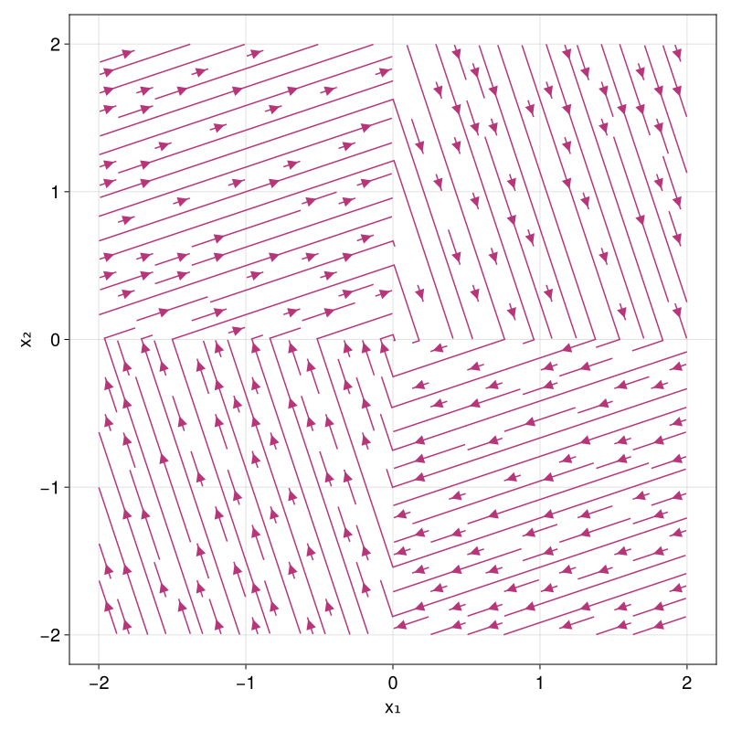

Figure 1: State portrait of the discontinuous system

```julia
f₁(x) = -sign(x[1]) + 2*sign(x[2])
f₂(x) = -2*sign(x[1]) - sign(x[2])
f(x) = [f₁(x), f₂(x)]

using CairoMakie
fig = Figure(size = (800, 800),fontsize=20)
ax = Axis(fig[1, 1], xlabel = "x₁", ylabel = "x₂")
streamplot!(ax,(x₁,x₂)->Point2f(f([x₁,x₂])), -2.0..2.0, -2.0..2.0, colormap = :magma)
fig
```

One particular (vector) state trajectory obtained by some default ODE solver is in Fig. 2.

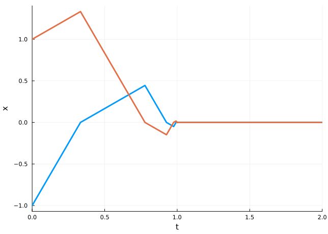

Figure 2: Trajectory of the discontinuous system

```julia
using DifferentialEquations

function f!(dx,x,p,t)
    dx[1] = -sign(x[1]) + 2*sign(x[2])
    dx[2] = -2*sign(x[1]) - sign(x[2])
end

x0 = [-1.0, 1.0]
tfinal = 2.0
tspan = (0.0,tfinal)
prob = ODEProblem(f!,x0,tspan)
sol = solve(prob)

using Plots
Plots.plot(sol,xlabel="t",ylabel="x",label=false,lw=3)
```

We can also plot the trajectory in the state space, as in Fig. 3.

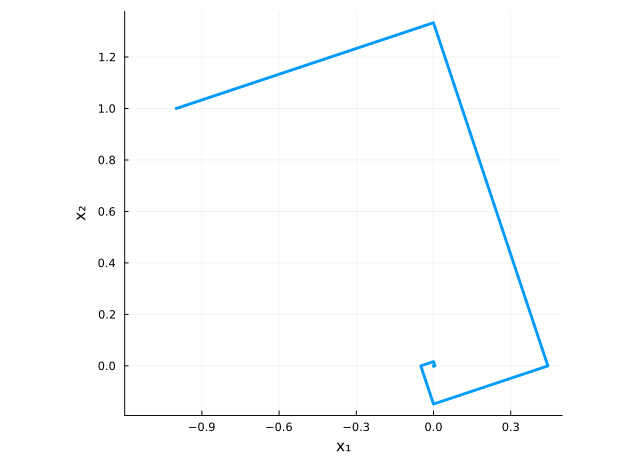

Figure 3: Trajectory of the discontinuous system in the state space

```julia
Plots.plot(sol[1,:],sol[2,:],xlabel="x₁",ylabel="x₂",label=false,aspect_ratio=:equal,lw=3,xlims=(-1.2,0.5))
```

Note that for the default setting of absolute and relative tolerances, the adaptive-step ODE solver actually needed a huge number of steps:

```julia
length(sol.t)
```

```
288594
```

This is indeed quite a lot. Can we do better?

In this particular example, we have the benefit of being able to analyze the solution analytically. In particular, we can ask: how fast does the solution approach the origin? We turn this into a question of how fast the distance from the origin decreases. With some anticipation we use the 1-norm $\|\bm x\|_1 = |x_1| + |x_2|$ to the distance of the state from the origin. We then ask:
$$\frac{\mathrm d}{\mathrm dt}\|\bm x\|_1 = ?$$

We avoid the troubles with nonsmoothness of the absolute value by considering each quadrant separately. Let’s start in the first (upper right) quadrant, that is, $x_1>0$ and $x_2>0$, from which it follows that $|x_1| = x_1, \;|x_2| = x_2$, and therefore
$$\frac{\mathrm d}{\mathrm dt}\|\bm x\|_1 = \dot x_1 + \dot x_2 = 1 - 3 = -2.$$

The situation is identical in the other quadrants. We do not worry that the norm is undefined on the axes, because the trajectory obviously just crosses them.

The conclusion is that the trajectory will hit the origin in *finite time* (!): with, say, $x_1(0) = 1$ and $x_2(0) = 1$, the trajectory hits the origin at $t=(|x_1(0)|+|x_2(0)|)/2 = 1$. Surprisingly (or not), this will happen after an infinite number of revolutions around the origin…

We have seen above in Fig. 2 that a default solver for ODE can handle the situation in a decent way. But we have also seen that this was at the cost of a huge number of steps. To get some insight, we implement our own solver.

#### Forward Euler with fixed step size

We start with the simplest of all methods, the forward Euler method with a fixed step length. The computation of the next state is done just by the assignment
$$\begin{aligned}
{\color{blue}x_{1,k+1}} &= x_{1,k} + h (-\operatorname{sign} x_{1,k} + 2 \operatorname{sign} x_{2,k})\\
{\color{blue}x_{2,k+1}} &= x_{2,k} + h (-2\operatorname{sign} x_{1,k} - \operatorname{sign} x_{2,k}).
\end{aligned}$$

**NoteBlue color in our text is used to denote the unknown**

We use the blue color here (and in the next few paragraphs) to highlight what is uknown.

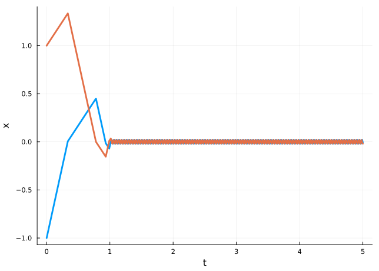

Figure 4: Solution trajectory for a discontinuous system obtained by the forward Euler method

```julia
f(x) = [-sign(x[1]) + 2*sign(x[2]), -2*sign(x[1]) - sign(x[2])]

using LinearAlgebra
N = 1000
x₀ = [-1.0, 1.0]
x = [x₀]
tfinal = norm(x₀,1)/2
tfinal = 5.0
h = tfinal/N
t = range(0.0, step=h, stop=tfinal)

for i=1:N
    xnext = x[i] + h*f(x[i])
    push!(x,xnext)
end

X = [getindex.(x, i) for i in 1:length(x[1])]

Plots.plot(t,X,lw=3,label=false,xlabel="t",ylabel="x")
```

Then number of steps is

```julia
length(t)
```

```
1001
```

which is significantly less than before, but the solution is not perfect – notice the chattering. It could be reduced by using a smaller step size, but again, at the cost of a longer simulation time.

#### Backward Euler

As an alternative to the forward Euler method, we can use the backward Euler method. The computation of the next state is done by solving the nonlinear equations
$$\begin{aligned}
{\color{blue} x_{1,k+1}} &= x_{1,k} + h (-\operatorname{sign} {\color{blue}x_{1,k+1}} + 2 \operatorname{sign} {\color{blue}x_{2,k+1}})\\
{\color{blue} x_{2,k+1}} &= x_{2,k} + h (-2\operatorname{sign} {\color{blue}x_{1,k+1}} - \operatorname{sign} {\color{blue}x_{2,k+1}}).
\end{aligned}$$

The discontinuities on the right-hand sides constitute a challenge for solvers of nonlinear equations – recall that the Newton’s method requires the first derivatives (assembled into the Jacobian) or their approximation. Instead of this struggle, we can use the *mixed complementarity problem* (MCP) formulation.

#### Formulation of the backward Euler as Mixed Complementarity Problem (MCP)

Instead solving the above nonlinear equations with discontinuities, we introduce new variables $u_1$ and $u_2$ as the outputs of the $\operatorname{sign}$ functions:
$$\begin{aligned}
{\color{blue} x_{1,k+1}} &= x_{1,k} + h (-{\color{blue}u_{1}} + 2 {\color{blue}u_{2}})\\
{\color{blue} x_{2,k+1}} &= x_{2,k} + h (-2{\color{blue}u_{1}} - {\color{blue}u_{2}}).
\end{aligned}$$

But now we have to enforce the **relationship** between $\bm u$ and $\bm x_{k+1}$. Recall the standard definition of the $\operatorname{sign}$ function is
$$\operatorname{sign}(x) = \begin{cases}
1 & x>0\\
0 & x=0\\
-1 & x<0,
\end{cases}$$
but we change the definition to a set-valued function
$$\begin{cases}
\operatorname{sign}(x) = 1 & x>0\\
\operatorname{sign}(x) \in [-1,1] & x=0\\
\operatorname{sign}(x) = -1 & x<0.
\end{cases}$$

Accordingly, we set the relationship between $\bm u$ and $\bm x$ to
$$\begin{cases}
u_1 = 1 & x_1>0\\
u_1 \in [-1,1] & x_1=0\\
u_1 = -1 & x_1<0,
\end{cases}$$
and
$$\begin{cases}
u_2 = 1 & x_2>0\\
u_2 \in [-1,1] & x_2=0\\
u_2 = -1 & x_2<0.
\end{cases}$$

But these are *mixed complementarity constraints* we have defined previously! We can thus write the single step of the simulation algorithm as the MCP
$$\boxed{
\begin{aligned}
\begin{bmatrix}
{\color{blue} x_{1,k+1}}\\
{\color{blue} x_{2,k+1}}
\end{bmatrix}
&=
\begin{bmatrix}
x_{1,k}\\
x_{2,k}
\end{bmatrix} + h
\begin{bmatrix}
-1 & 2 \\
-2 & -1
\end{bmatrix}
\begin{bmatrix}
{\color{blue}u_{1}}\\
{\color{blue}u_{2}}
\end{bmatrix}\\
-1 &\leq {\color{blue} u_1} \leq 1 \quad \bot \quad -{\color{blue}x_{1,k+1}}\\
-1 &\leq {\color{blue} u_2} \leq 1 \quad \bot \quad -{\color{blue}x_{2,k+1}}.
\end{aligned}
}
\tag{1}$$

We now have enough to start implementing a solver for this system, provided we have an access to a solver the MCP (see the page dedicated to software for complementarity problems). But before we do it, we analyze the problem a bit deeper. In this particular small and simple case, it is still doable with just a pencil and paper.

#### 9 possible combinations

There are now 9 possible combinations of the values of $u_1$ and $u_2$, each of them strictly inside their respective intervals, or at the either end. Let’s explore some combinations. We start with $x_{1,k+1} = x_{2,k+1} = 0$, while $u_1 \in [-1,1]$ and $u_2 \in [-1,1]$:

$$\begin{aligned}
\begin{bmatrix}
0\\
0
\end{bmatrix}
&=
\begin{bmatrix}
x_{1,k}\\
x_{2,k}
\end{bmatrix} + h
\begin{bmatrix}
-1 & 2 \\
-2 & -1
\end{bmatrix}
\begin{bmatrix}
{\color{blue}u_{1}}\\
{\color{blue}u_{2}}
\end{bmatrix}\\
& -1 \leq {\color{blue} u_1} \leq 1, \quad -1 \leq {\color{blue} u_2} \leq 1
\end{aligned}$$

How does the set of states from which the next state is zero look like? We isolate the vector $\bm u$ from the equation and impose the constraints on it:
$$\begin{aligned}
-\begin{bmatrix}
-1 & 2 \\
-2 & -1
\end{bmatrix}^{-1}
\begin{bmatrix}
x_{1,k}\\
x_{2,k}
\end{bmatrix}
&= h
\begin{bmatrix}
{\color{blue}u_{1}}\\
{\color{blue}u_{2}}
\end{bmatrix}\\
-1 \leq {\color{blue} u_1} \leq 1, \quad -1 &\leq {\color{blue} u_2} \leq 1
\end{aligned}$$

We then get
$$\begin{bmatrix}
-h\\-h
\end{bmatrix}
\leq
\begin{bmatrix}
0.2 & 0.4 \\
-0.4 & 0.2
\end{bmatrix}
\begin{bmatrix}
x_{1,k}\\
x_{2,k}
\end{bmatrix}
\leq
\begin{bmatrix}
h\\ h
\end{bmatrix}$$

For $h=0.2$, the resulting set is a rotated square, as shown in Fig. 5.

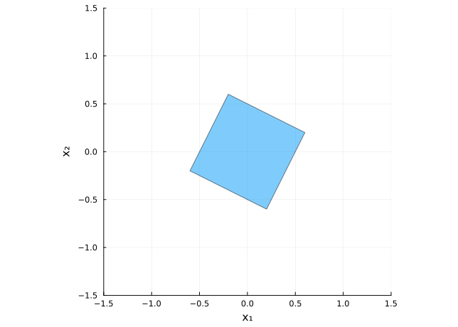

Figure 5: The set of states from which the next state is zero (the origin)

```julia
using LazySets
h = 0.2
H1u = HalfSpace([0.2, 0.4], h)
H2u = HalfSpace([-0.4, 0.2], h)
H1l = HalfSpace(-[0.2, 0.4], h)
H2l = HalfSpace(-[-0.4, 0.2], h)

Ha = H1u ∩ H2u ∩ H1l ∩ H2l

using Plots
Plots.plot(Ha, aspect_ratio=:equal,xlabel="x₁",ylabel="x₂",label=false,xlims=(-1.5,1.5),ylims=(-1.5,1.5))
```

Indeed, if the current state is in this rotated square, then the next state will be zero. No more infite spiralling around the origin! No more chattering! Perfect zero.

#### Another combination

We now consider $u_1 = 1$, $u_2 = 1$, which we substitute into Eq. 1:
$$\begin{aligned}
\begin{bmatrix}
{\color{blue} x_{1,k+1}}\\
{\color{blue} x_{2,k+1}}
\end{bmatrix}
&=
\begin{bmatrix}
x_{1,k}\\
x_{2,k}
\end{bmatrix} + h
\begin{bmatrix}
-1 & 2 \\
-2 & -1
\end{bmatrix}
\begin{bmatrix}
{1}\\
{1}
\end{bmatrix}\\
\color{blue}x_{1,k+1} &\geq 0\\
\color{blue}x_{2,k+1} &\geq 0,
\end{aligned}$$
which can be reformatted to
$$\begin{bmatrix}
x_{1,k}\\
x_{2,k}
\end{bmatrix} + h
\begin{bmatrix}
-1 & 2 \\
-2 & -1
\end{bmatrix}
\begin{bmatrix}
1\\
1
\end{bmatrix}\geq \bm 0,$$
and further to
$$\begin{bmatrix}
x_{1,k}\\
x_{2,k}
\end{bmatrix}
\geq h
\begin{bmatrix}
-1\\
3
\end{bmatrix}.$$

The set of states for which the next state is such that both its state variables are positive (hence $u_1 = 1$, $u_2 = 1$) is shown in Fig. 6.

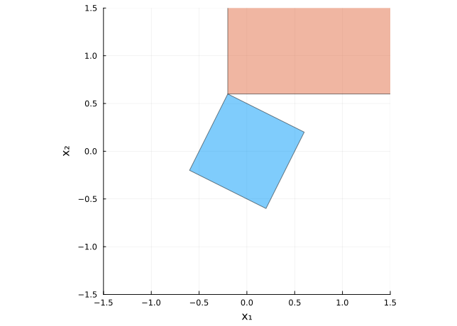

Figure 6: The set of states from which the next state has both state variables positive

```julia
using LazySets
h = 0.2
A = [-1.0 2.0; -2.0 -1.0]
u = [1.0, 1.0]
b = h*A*u

H1 = HalfSpace([-1.0, 0.0], b[1])
H2 = HalfSpace([0.0, -1.0], b[2])
Hb = H1 ∩ H2

using Plots
Plots.plot(Ha, aspect_ratio=:equal,xlabel="x₁",ylabel="x₂",label=false,xlims=(-1.5,1.5),ylims=(-1.5,1.5))
Plots.plot!(Hb)
```

#### All nine regions

We plot all nine regions in Fig. 7. Note that we do not color them all – the white regions are to be counted as well.

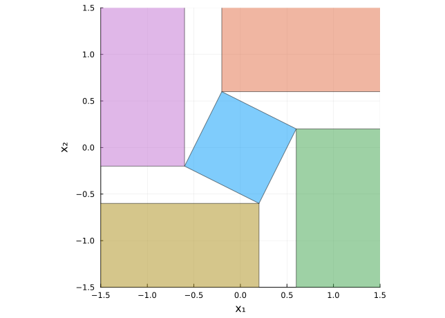

Figure 7: The nine regions of the state space for the spiralling system

```julia
using LazySets
h = 0.2
A = [-1.0 2.0; -2.0 -1.0]

u = [1, -1]
b = h*A*u

H1 = HalfSpace(-[1.0, 0.0], b[1])
H2 = HalfSpace([0.0, 1.0], -b[2])
Hc = H1 ∩ H2

u = [-1, 1]
b = h*A*u

H1 = HalfSpace([1.0, 0.0], -b[1])
H2 = HalfSpace(-[0.0, 1.0], b[2])
Hd = H1 ∩ H2

u = [-1, -1]
b = h*A*u

H1 = HalfSpace([1.0, 0.0], -b[1])
H2 = HalfSpace([0.0, 1.0], -b[2])
He = H1 ∩ H2

using Plots
Plots.plot(Ha, aspect_ratio=:equal,xlabel="x₁",ylabel="x₂",label=false,xlims=(-1.5,1.5),ylims=(-1.5,1.5))
Plots.plot!(Hb)
Plots.plot!(Hc)
Plots.plot!(Hd)
Plots.plot!(He)
```

#### Solutions using a MCP solver

Now that we have got some insight into the algorithm, we can implement it by wrapping a for-loop around the MCP solver.

```julia
M = [-1 2; -2 -1]
h = 2e-1
tfinal = 2.0
N = tfinal/h

x0 = [-1.0, 1.0]
x = [x0]

using JuMP
using PATHSolver

for i = 1:N
    model = Model(PATHSolver.Optimizer)
    set_optimizer_attribute(model, "output", "no")
    set_silent(model)
    @variable(model, -1 <= u[1:2] <= 1)
    @constraint(model, -h*M * u - x[end] ⟂ u)
    optimize!(model)
    push!(x, x[end]+h*M*value.(u))
end
```

The code is admittedly unoptimized (for example, it is not wise to start building the optimization model from the scratch in every iteration), but it was our intention to keep it simple to be read conveniently.

The code outcome can be plotted as in Fig. 8. A solution obtained by a classical (default) ODE solver with default setting is plotted for comparison.

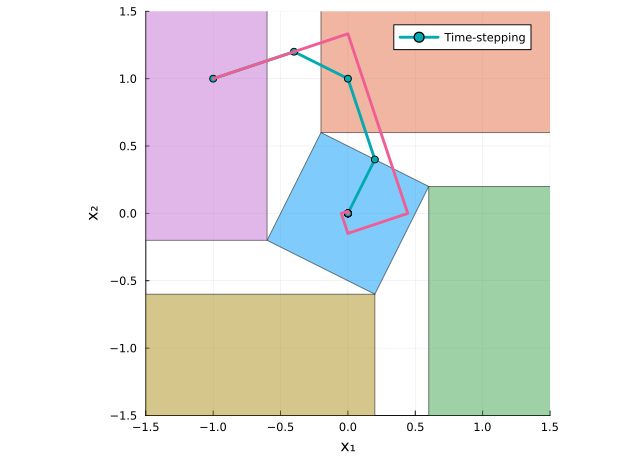

Figure 8: Solution trajectory for a discontinuous system obtained by the MCP solver

```julia
t = range(0.0, step=h, stop=tfinal)
X = [getindex.(x, i) for i in 1:length(x[1])]

using Plots
Plots.plot(Ha, aspect_ratio=:equal,xlabel="x₁",ylabel="x₂",label=false,xlims=(-1.5,1.5),ylims=(-1.5,1.5))
Plots.plot!(Hb)
Plots.plot!(Hc)
Plots.plot!(Hd)
Plots.plot!(He)
Plots.plot!(X[1],X[2],xlabel="x₁",ylabel="x₂",label="Time-stepping",aspect_ratio=:equal,lw=3,markershape=:circle)
Plots.plot!(sol[1,:],sol[2,:],label=false,lw=3)
```

It is worth emphasizing that once the solution trajectory hits the blue square, it is just one step from the origin. And once the solution trajectory reaches the origin, it stays there forever, no more spiralling, no more chattering.

Apparently, the chosen step length was too large. If we reduce it, the resulting trajectory resembles the one obtained by a default ODE solver, as shown in Fig. 9.

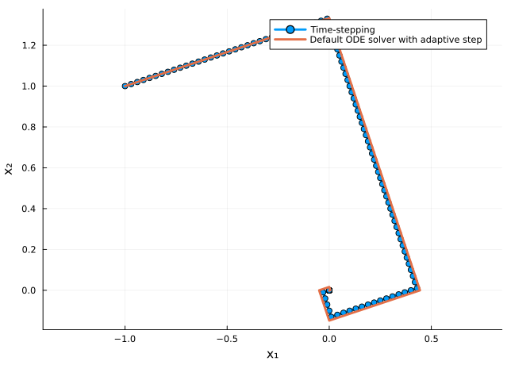

Figure 9: Solution trajectory for a discontinuous system obtained by the MCP solver with a smaller step size

```julia
M = [-1 2; -2 -1]
h = 1e-2
tfinal = 2.0
N = tfinal/h

x0 = [-1.0, 1.0]
x = [x0]

using JuMP
using PATHSolver

for i = 1:N
    model = Model(PATHSolver.Optimizer)
    set_optimizer_attribute(model, "output", "no")
    set_silent(model)
    @variable(model, -1 <= u[1:2] <= 1)
    @constraint(model, -h*M * u - x[end] ⟂ u)
    optimize!(model)
    push!(x, x[end]+h*M*value.(u))
end

t = range(0.0, step=h, stop=tfinal)
X = [getindex.(x, i) for i in 1:length(x[1])]

Plots.plot(X[1],X[2],xlabel="x₁",ylabel="x₂",label="Time-stepping",aspect_ratio=:equal,lw=3,markershape=:circle)
Plots.plot!(sol[1,:],sol[2,:],lw=3,label="Default ODE solver with adaptive step")
```

And yet the total number of steps is still much smaller:

```julia
length(t)
```

```
201
```

**Example 2 (Time-stepping for a mechanical system with a hard stop)** Let’s now apply the time-stepping method for a mechanical system with a hard stop as described in the Example 2 in the section on complementarity systems. We start by formulating the *semi-explicit* Euler scheme

$$\begin{aligned}
\bm x_{k+1} &= \bm x_k + h \bm v_{k+1}\\
\bm v_{k+1} &= \bm v_k + h \mathbf A \bm x_{k} + h \mathbf B \bm u_k,
\end{aligned}$$
where
$$\mathbf A = \begin{bmatrix} -\frac{k_1+k2}{m_1} & \frac{k_2}{m_1}\\ \frac{k_2}{m_2} & -\frac{k_2}{m_2} \end{bmatrix}, \quad
\mathbf B = \begin{bmatrix} \frac{1}{m_1} & -\frac{1}{m_1}\\ 0 & \frac{1}{m_2} \end{bmatrix}.$$

Substituting from the second to the first equation, we get
$${\color{blue}\bm x_{k+1}} = \bm x_k + h \bm v_k + h^2 \mathbf A \bm x_k + h^2 \mathbf B {\color{blue}\bm u_k},$$
in which we again highlight the unknown terms by blue color for convenience. These two vector unknowns must satisfy the following complementarity condition
$$0 \leq x_{1,k+1} \perp u_{1,k} \geq 0,$$
and
$$0 \leq (x_{2,k+1} - x_{1,k+1}) \perp u_{2,k} \geq 0.$$

This can be written compactly as
$$\bm 0 \leq \mathbf C \bm x_{k+1} \perp \bm u_{k} \geq 0,$$
where $\mathbf C$ is known from the previous section as
$$\mathbf C = \begin{bmatrix}1 & 0\\ -1 & 1\end{bmatrix}.$$

The constraint can be expanded into
$$\bm 0 \leq \mathbf C\left(\bm x_k + h \bm v_k + h^2 \mathbf A \bm x_k + h^2 \mathbf B {\color{blue}\bm u_k}\right) \perp \bm u_{k} \geq 0,$$
which is an LCP problem with
$$\bm q = \mathbf C\left(\bm x_k + h \bm v_k + h^2 \mathbf A \bm x_k\right)$$
and
$$\mathbf M = h^2 \mathbf C \mathbf B.$$

An implementation of the time-stepping for this system is shown below.

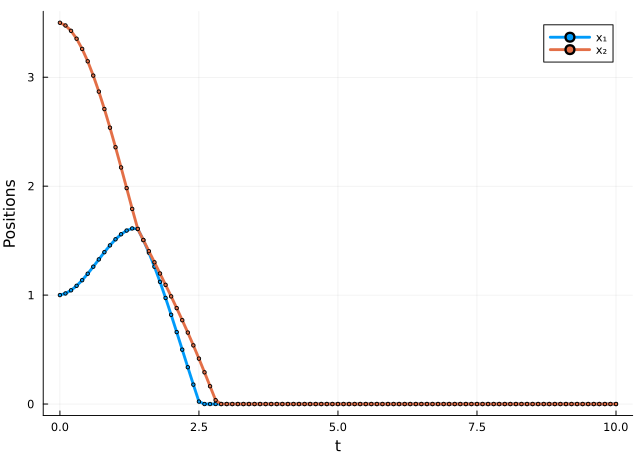

Figure 10: Simulation of a two-cart-spring mechanical system with a hard stop using a time-stepping numerical scheme. At first, both carts move towards each other unil their collision, after which they both accelerate towards the hard stop located at zero, the first cart a bit more, untill they collide again at the hard stop.

```julia
m1 = 1.0
m2 = 1.0
k1 = 1.0
k2 = 1.0

A = [-(k1+k2)/m1 k2/m1; k2/m2 -k2/m2]
B = [1/m1 -1/m1; 0 1/m2]
h = 1e-1

x10 = 1.0
x20 = 3.5
v10 = 0.0
v20 = 0.0

x0 = [x10, x20]
v0 = [v10, v20]

x = [x0]
v = [v0]

tfinal = 10.0
N = tfinal/h

for i = 1:N
    model = Model(PATHSolver.Optimizer)
    set_optimizer_attribute(model, "output", "no")
    set_silent(model)
    @variable(model, u[1:2] >= 0)
    @constraint(model, [1 0; -1 1]*(h^2*B*u + x[end] + h*v[end] + h^2*A*x[end]) ⟂ u)
    optimize!(model)
    push!(x, h^2*B*value.(u) + (x[end] + h*v[end] + h^2*A*x[end]))
    push!(v, v[end] + h*A*x[end] + h*B*value.(u))
end

t = range(0.0, step=h, stop=tfinal)
X = [getindex.(x, i) for i in 1:length(x[1])]

Plots.plot(t,X[1],label="x₁",lw=3,xlabel="t",ylabel="Positions",markershape=:circle,markersize=2)
Plots.plot!(t,X[2],label="x₂",lw=3,markershape=:circle,markersize=2)
```

Note, once again, the amazingly small number of steps

```julia
length(t)
```

```
101
```

while the shape of the trajectory is already quite accurate (you can try reducing the step lenght by yourself) and whatever chattering is absent in the solution.

**Example 3 (Time stepping for a mechanical system with Coulomb friction modelled as complementarity constraints)** We consider an object of mass $m$ moving on a horizontal surface. The object is subject to an applied force $F_\mathrm{a}$ and a friction force $F_\mathrm{f}$, both oriented in the positive direction of position and velocity, as in Fig. 11.

[figure not shown]

Figure 11: Coulomb friction to be modelled using complementarity constraints

The friction force is modelled as a Coulomb friction model
$$F_\mathrm{f}(t) = -m g \mu\, \mathrm{sgn}(v(t)),$$
where $\mu$ is a coefficient that relates the frictional force to the normal force $mg$.

The motion equations are
$$\begin{aligned}
\dot x(t) &= v(t)\\
\dot v(t) &= \frac{1}{m}(F_\mathrm{a}(t) + F_\mathrm{f}(t)).
\end{aligned}$$

We now express the friction force as a difference of two nonnegative variables
$$F_\mathrm{f}(t) = F^+_\mathrm{f}(t) - F^-_\mathrm{f}(t),\quad F^+_\mathrm{f}(t), \,F^-_\mathrm{f}(t) \geq 0.$$

And we also introduce another auxiliary variable $\nu(t)$ that is just the absolute value of the velocity
$$\nu(t) \coloneqq |v(t)|.$$

With the three new variables we formulate the Coulomb friction model as
$$\begin{aligned}
0 \leq v + \nu &\perp F^+_\mathrm{f} \geq 0,\\
0 \leq -v + \nu &\perp F^-_\mathrm{f} \geq 0, \\
0 \leq \mu m g - F^+_\mathrm{f} - F^-_\mathrm{f} &\perp \nu \geq 0.
\end{aligned}$$

If $F^-_\mathrm{f} > 0$, that is, if the friction force is negative, the second complementarity constraint implies that the velocity is equal to its absolute value, in other words, it is nonnegative, the object moves to the right (or stays still). If the velocity is positive, the first constraint implies that $F^+_\mathrm{f} = 0$, and the third constraint then implies that $F^-_\mathrm{f} = mg\mu$. Feel free to explore other cases.

We now proceed to implement the time-stepping method for this system. Once again, we use the semi-explicit Euler scheme
$$\begin{aligned}
x_{k+1} &= x_k + h v_{k+1},\\
v_{k+1} &= v_k + \frac{h}{m} (F^+_{\mathrm{f},k} - F^-_{\mathrm{f},k} + F_{\mathrm{a},k}),
\end{aligned}$$
where the velocity is subject to the complementarity constraints
$$\begin{aligned}
0 \leq v_{k+1} + \nu_{k+1} &\perp F^+_{\mathrm{f},k} \geq 0,\\
0 \leq -v_{k+1} + \nu_{k+1} &\perp F^-_{\mathrm{f},k} \geq 0, \\
0 \leq \mu m g - F^+_{\mathrm{f},k} - F^-_{\mathrm{f},k} &\perp \nu_{k+1} \geq 0,
\end{aligned}$$
into which we substitute for $v_{k+1}$
$$\boxed{
\begin{aligned}
0 \leq v_k + \frac{h}{m} ({\color{blue}F^+_{\mathrm{f},k}} - {\color{blue}F^-_{\mathrm{f},k}} + F_{\mathrm{a},k}) + {\color{blue}\nu_{k+1}}\, &\perp\, {\color{blue}F^+_{\mathrm{f},k}} \geq 0,\\
0 \leq -\left(v_k + \frac{h}{m} ({\color{blue}F^+_{\mathrm{f},k}} - {\color{blue}F^-_{\mathrm{f},k}} + F_{\mathrm{a},k})\right) + {\color{blue}\nu_{k+1}}\, &\perp\, {\color{blue}F^-_{\mathrm{f},k}} \geq 0, \\
0 \leq \mu m g - {\color{blue}F^+_{\mathrm{f},k}} - {\color{blue}F^-_{\mathrm{f},k}} \,&\perp\, {\color{blue}\nu_{k+1}} \geq 0,
\end{aligned}
}$$
in which we highlighted the unknowns by blue color for convenience.

In the simulation below, we set the applied force to zero, $F_{\mathrm{a},k} = 0$, and we only simulate the response to some nonzero initial velocity. The simulation outcomes in Fig. 12 show that the object comes to a complete stop due to friction, as expected.

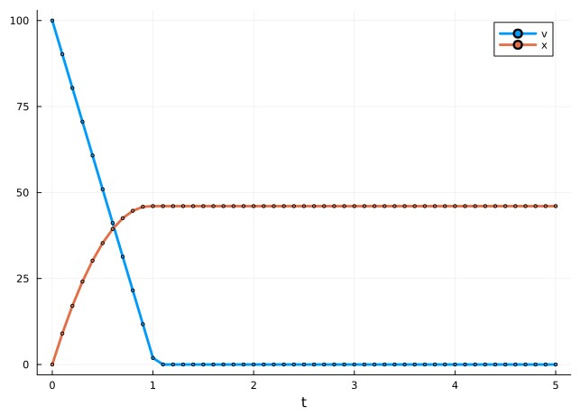

Figure 12: Simulation of an object moving on a horizontal surface with Coulomb friction using a time-stepping numerical scheme in which the friction force is modelled using complementarity constraints. The object starts with an initial velocity and comes to a complete stop due to friction.

```julia
using JuMP
using PATHSolver
using Plots

m = 100.0
g = 9.81
μ = 10.0

x0 = 0.0
v0 = 100.0

x = [x0]
v = [v0]

h = 1e-1
tfinal = 5.0
N = tfinal/h

for i = 1:N
    model = Model(PATHSolver.Optimizer)
    set_optimizer_attribute(model, "output", "no")
    set_silent(model)
    @variable(model, ν >= 0)
    @variable(model, F⁺ >= 0)
    @variable(model, F⁻ >= 0)
    @constraint(model, (v[end] + h/m*(F⁺-F⁻) + ν) ⟂ F⁺)
    @constraint(model, (-(v[end] + h/m*(F⁺-F⁻)) + ν) ⟂ F⁻)
    @constraint(model, (μ*m*g - (F⁺+F⁻)) ⟂ ν)
    optimize!(model)
    push!(v, v[end] + h/m*(value(F⁺)-value(F⁻)))
    push!(x, x[end] + h*v[end])         # At this point, after the update on the prevous line, v[end] already equals v_k+1.
end

t = range(0.0, step=h, stop=tfinal)
Plots.plot(t, v, label="v", lw=3, markershape=:circle, markersize=2)
Plots.plot!(t, x, label="x", lw=3, markershape=:circle, markersize=2, xlabel="t")
```

Modification of this example to model the situation of an object sliding down on and inclided plane is left as an exercise to the reader. Hint: the normal force that parametrizes the friction force will depend on the angle too, and the applied force $F_\mathrm{a}$ that we did not use here can be used to model the component of the gravity force that is parallel to the inclined plane. Obviously, the angle of the inclination and the friction coefficient must be such that the object that starts at some nonzero initial velocity eventually comes to a complete stop. Writing down such condition is a part of the exercise.

**Important**

While concluding this section about time-stepping methods, we have to emphasize that this was really just an introduction. But the essence of using complementarity concepts in numerical simulation is perhaps a bit clearer now.

Back to top